# Statistical tests

Day 3 - Introduction to Data Analysis with R

Selina Baldauf

Freie Universität Berlin - Theoretical Ecology

October 17, 2026

## General approach

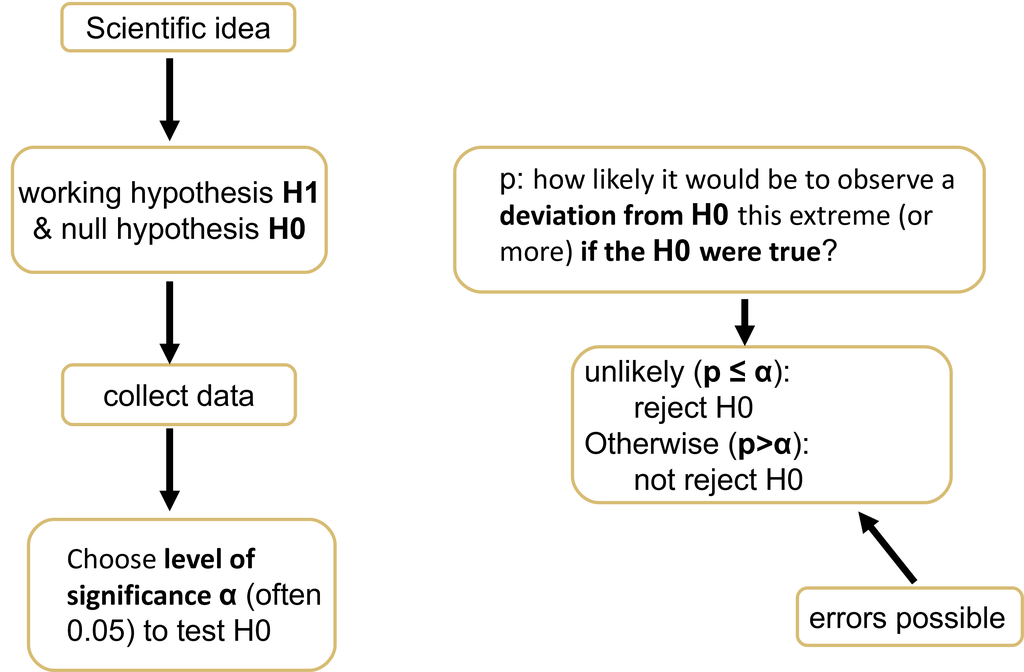

Please note the discussion about p-values as a basis for binary decisions. See e.g. [here](https://www.nature.com/articles/s41592-019-0470-3) or [here](https://www.nature.com/articles/d41586-019-00857-9) as a starting point

## Tests to compare two groups

**t-test**

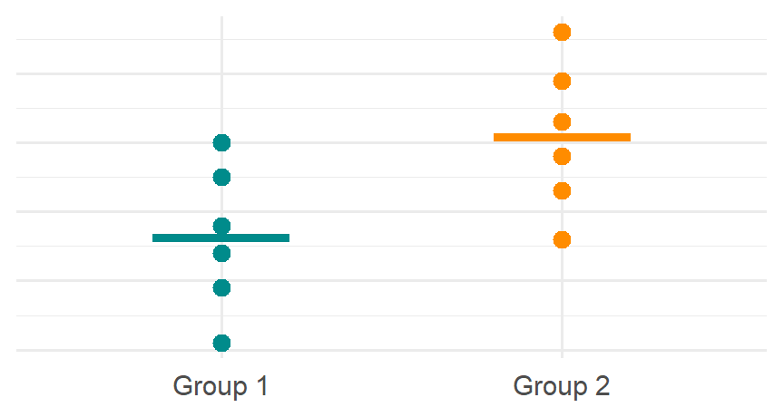

- Compares the **means** of two groups
- Suitable for roughly normal data, or for larger samples
- 2 versions: Student’s (equal variance) and Welch’s t-test
  - Welch’s t-test is a good default

**Wilcoxon rank-sum test**

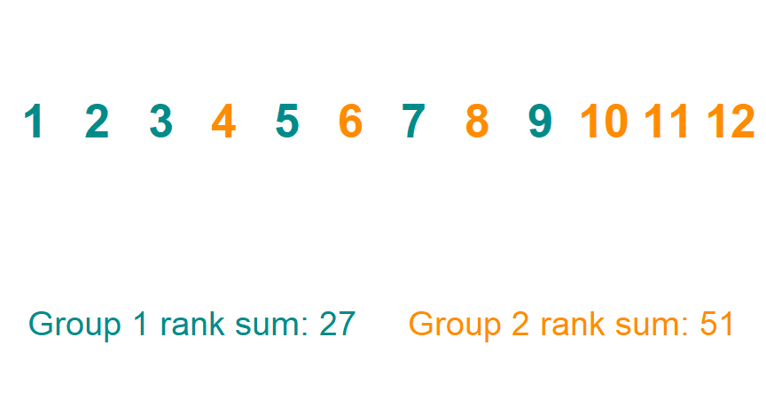

- Compares **ranks**: does one group tend to have larger values?
- Useful for ordinal data, skewed small samples, or outliers

## The data: iris

**Question:** Does the sepal width differ between *I. versicolor* and *I. virginica*?

**Reproduce the data**

```r
flowers <- as_tibble(iris) |>
  filter(Species %in% c("versicolor", "virginica")) |>
  select(sepal_width = Sepal.Width, species = Species) |>
  droplevels()
```

```r
flowers
```

```
#> # A tibble: 100 × 2
#>    sepal_width species
#>          <dbl> <fct>
#>  1         3.2 versicolor
#>  2         3.2 versicolor
#>  3         3.1 versicolor
#>  4         2.3 versicolor
#>  5         2.8 versicolor
#>  6         2.8 versicolor
#>  7         3.3 versicolor
#>  8         2.4 versicolor
#>  9         2.9 versicolor
#> 10         2.7 versicolor
#> # ℹ 90 more rows
```

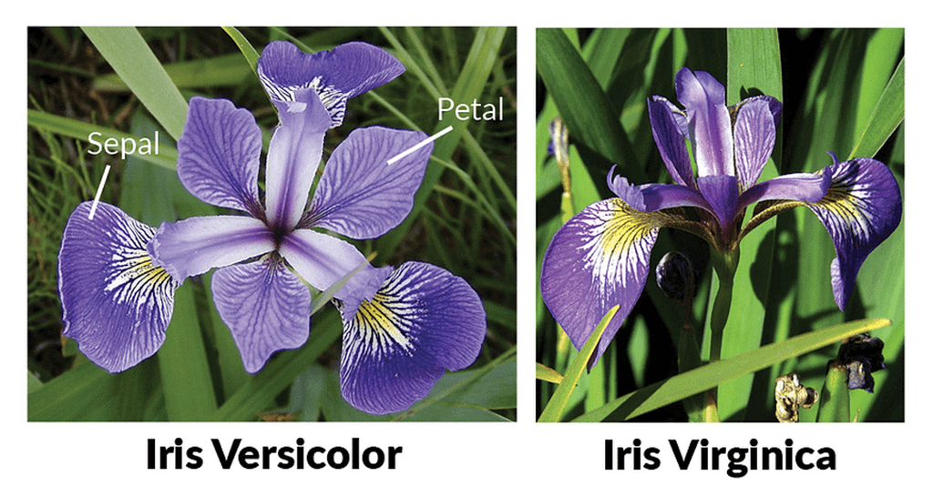

Image from [medium.com](https://medium.com/data-science/k-medoids-clustering-on-iris-data-set-1931bf781e05)

Sepal width (in cm) of 50 flowers from each of two iris species

## First look at the data

```r
flowers |>
  summarize(
    n = n(),
    mean = mean(sepal_width),
    sd = sd(sepal_width),
    .by = species
  )
```

```
#> # A tibble: 2 × 4
#>   species        n  mean    sd
#>   <fct>      <int> <dbl> <dbl>
#> 1 versicolor    50  2.77 0.314
#> 2 virginica     50  2.97 0.322
```

**Code for the boxplot**

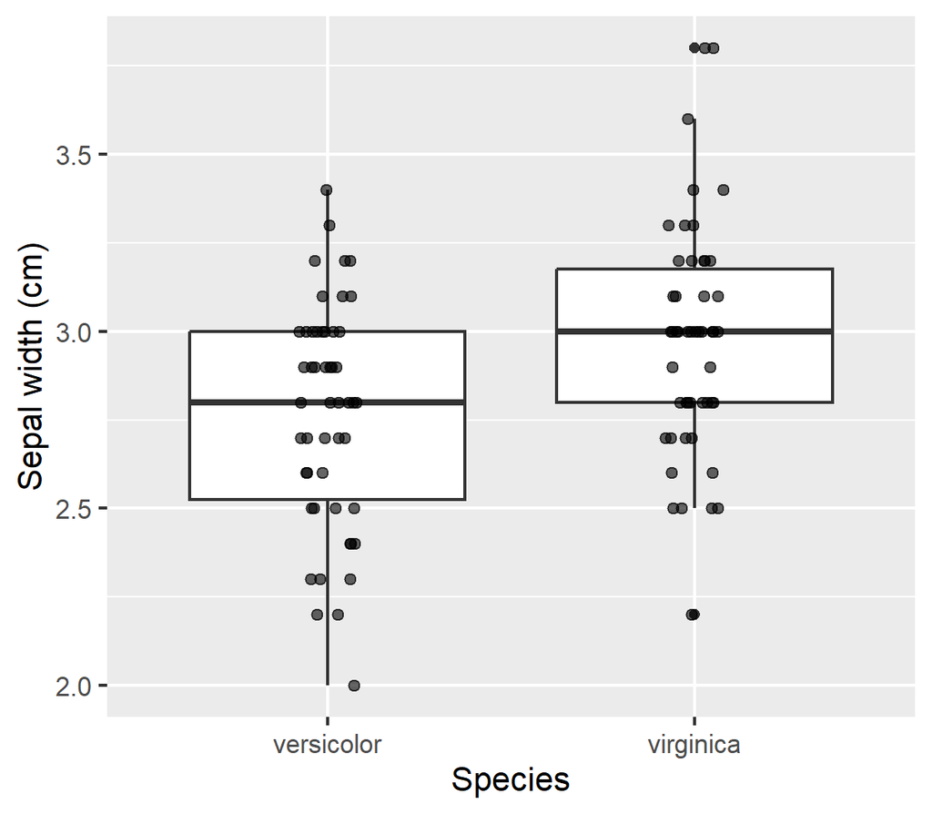

```r
ggplot(flowers, aes(x = species, y = sepal_width)) +
  geom_boxplot() +
  geom_point(
    position = position_jitter(width = 0.08, height = 0, seed = 123),
    alpha = 0.6
  ) +
  labs(x = "Species", y = "Sepal width (cm)")
```

## Prepare the group vectors

Most test functions take the values of each group as a vector

```r
versicolor <- filter(flowers, species == "versicolor")$sepal_width
virginica <- filter(flowers, species == "virginica")$sepal_width
```

```r
versicolor
```

```
#>  [1] 3.2 3.2 3.1 2.3 2.8 2.8 3.3 2.4 2.9 2.7 2.0 3.0 2.2 2.9 2.9 3.1 3.0 2.7 2.2
#> [20] 2.5 3.2 2.8 2.5 2.8 2.9 3.0 2.8 3.0 2.9 2.6 2.4 2.4 2.7 2.7 3.0 3.4 3.1 2.3
#> [39] 3.0 2.5 2.6 3.0 2.6 2.3 2.7 3.0 2.9 2.9 2.5 2.8
```

## Shapiro-Wilk test for normality

$H_0$: The data come from a normal distribution

```r
shapiro.test(versicolor)
```

```
#>
#>  Shapiro-Wilk normality test
#>
#> data:  versicolor
#> W = 0.97413, p-value = 0.338
```

```r
shapiro.test(virginica)
```

```
#>
#>  Shapiro-Wilk normality test
#>
#> data:  virginica
#> W = 0.96739, p-value = 0.1809
```

- A **large p-value**: no evidence against normality, can not reject $H_0$
- With large samples, very small deviations can give small p-values
- Always look at the data as well

## Normality with QQ-plots

Points should roughly follow the line. Look at the **tails** and at **unusual observations**.

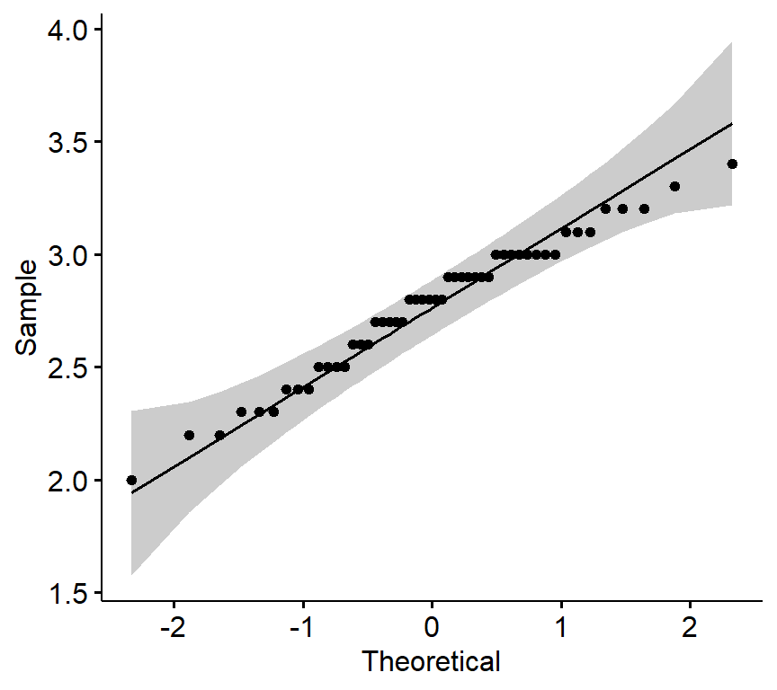

```r
ggpubr::ggqqplot(versicolor)
```

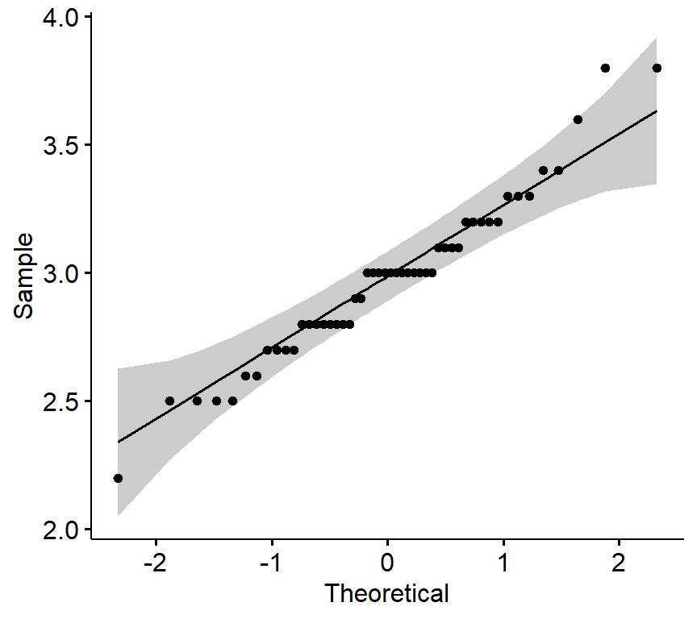

```r
ggpubr::ggqqplot(virginica)
```

Both species: no clear deviation from normality

## What does non-normal data look like?

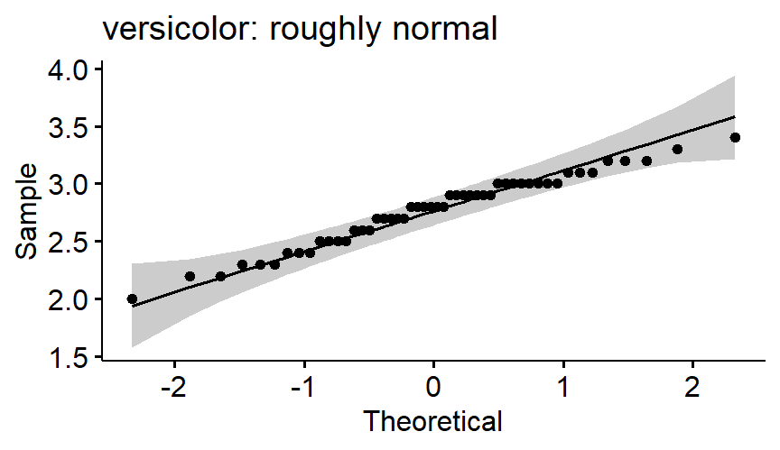

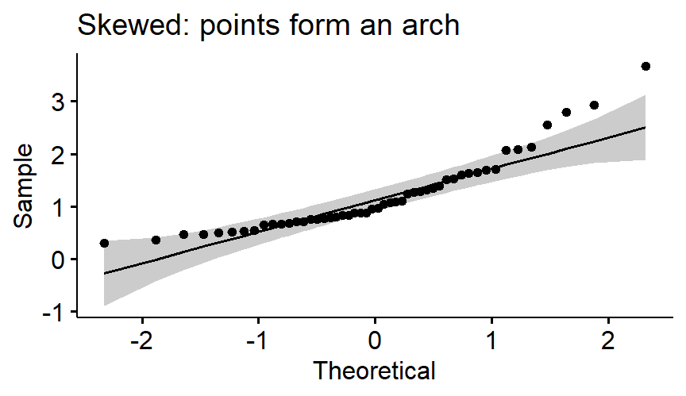

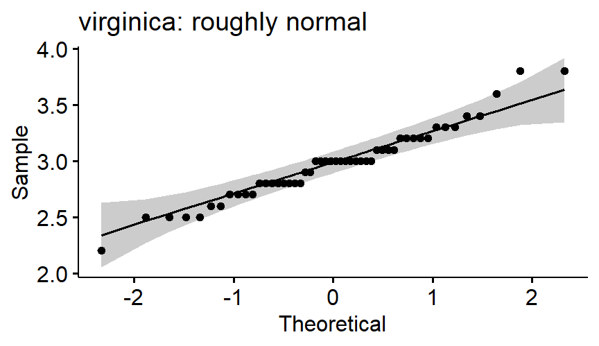

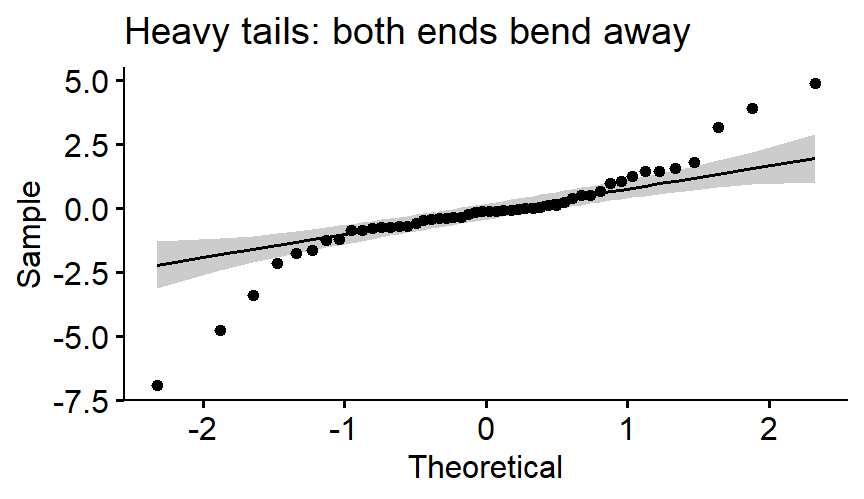

## Compare two means: Welch’s t-test

$H_0$: The means of the two groups do not differ

```r
t.test(versicolor, virginica)
```

```
#>
#>  Welch Two Sample t-test
#>
#> data:  versicolor and virginica
#> t = -3.2058, df = 97.927, p-value = 0.001819
#> alternative hypothesis: true difference in means is not equal to 0
#> 95 percent confidence interval:
#>  -0.33028364 -0.07771636
#> sample estimates:
#> mean of x mean of y
#>     2.770     2.974
```

- t: test statistic (t = 0 if the means are equal)
- p-value: How likely is a difference at least this large if the means were equal?
- Reject $H_0$

Mean sepal width was **0.20 cm smaller** in *I. versicolor* than in *I. virginica* (Welch’s t-test, $t_{97.9}$ = -3.21, p = 0.002).

## Wilcoxon rank-sum test

$H_0$: Neither group tends to have larger values than the other

- All values are ranked from smallest to largest
- The test compares the ranks of the two groups
- **Demonstration only:** the iris data don’t need a rank-based test, t-test was fine here

```r
wilcox.test(versicolor, virginica)
```

```
#>
#>  Wilcoxon rank sum test with continuity correction
#>
#> data:  versicolor and virginica
#> W = 841, p-value = 0.004572
#> alternative hypothesis: true location shift is not equal to 0
```

Sepal width tended to be smaller in *I. versicolor* than in *I. virginica* (Wilcoxon rank-sum test, W = 841, p = 0.005).

## Paired observations

Examples of paired observations:

- Blood pressure of patients before and after medication
- Difference in sleep quality of people as children and adults
- Biodiversity in rivers before and after a power plant …

In `sleep`, the **same 10 people** received two drugs (`extra`: extra sleep in hours)

**Reproduce the data**

```r
sleep_paired <- sleep |>
  pivot_wider(
    names_from = group,
    names_prefix = "drug_",
    values_from = extra
  )
```

```r
sleep_paired
```

```
#> # A tibble: 10 × 3
#>    ID    drug_1 drug_2
#>    <fct>  <dbl>  <dbl>
#>  1 1        0.7    1.9
#>  2 2       -1.6    0.8
#>  3 3       -0.2    1.1
#>  4 4       -1.2    0.1
#>  5 5       -0.1   -0.1
#>  6 6        3.4    4.4
#>  7 7        3.7    5.5
#>  8 8        0.8    1.6
#>  9 9        0      4.6
#> 10 10       2      3.4
```

## Paired observations

```r
t.test(
  sleep_paired$drug_1,
  sleep_paired$drug_2,
  paired = TRUE
)
```

```
#>
#>  Paired t-test
#>
#> data:  sleep_paired$drug_1 and sleep_paired$drug_2
#> t = -4.0621, df = 9, p-value = 0.002833
#> alternative hypothesis: true mean difference is not equal to 0
#> 95 percent confidence interval:
#>  -2.4598858 -0.7001142
#> sample estimates:
#> mean difference
#>           -1.58
```

Also: `wilcox.test(..., paired = TRUE)`

People slept **1.58 h longer** with drug 2 than with drug 1 (paired t-test, $t_9$ = -4.06, p = 0.003).

# Visualizing test results

## Boxplot to show differences

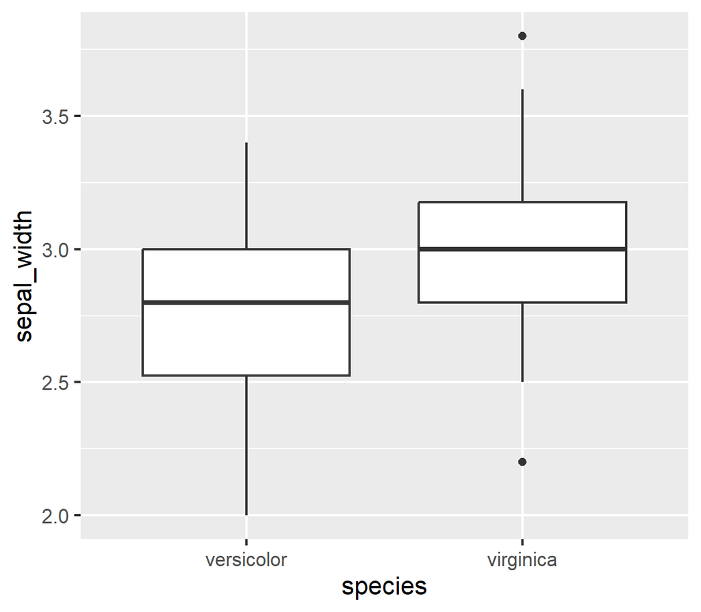

```r
ggplot(
  flowers,
  aes(x = species, y = sepal_width)
) +
  geom_boxplot()
```

## Add a test with `geom_signif()`

The [`ggsignif`](https://const-ae.github.io/ggsignif/) package adds significance levels to a ggplot

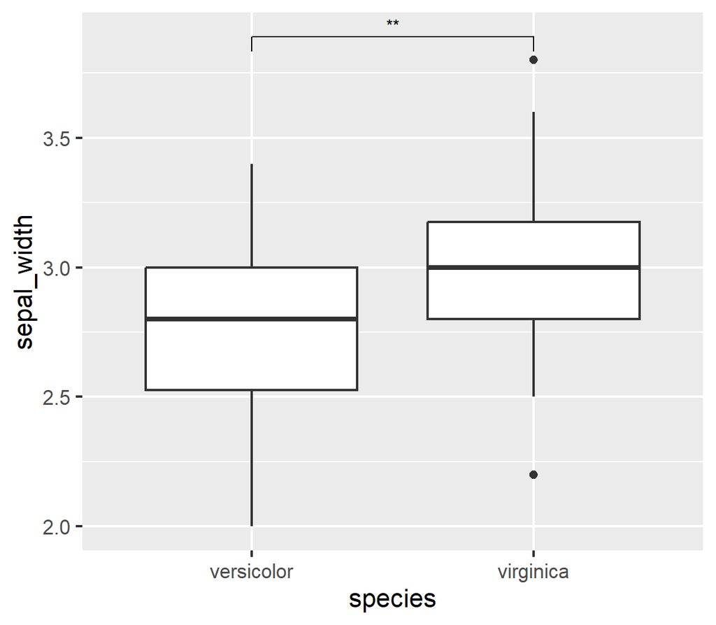

```r
# install.packages("ggsignif")
library(ggsignif)

ggplot(
  flowers,
  aes(x = species, y = sepal_width)
) +
  geom_boxplot() +
  geom_signif(
    comparisons = list(
      c("versicolor", "virginica")
    ),
    test = "t.test",
    map_signif_level = TRUE
  )
```

- `test = "t.test"`: Welch’s t-test (the default is a Wilcoxon test)
- `map_signif_level = TRUE`: stars, `FALSE`: p-value

## Plot means with `stat_summary()`

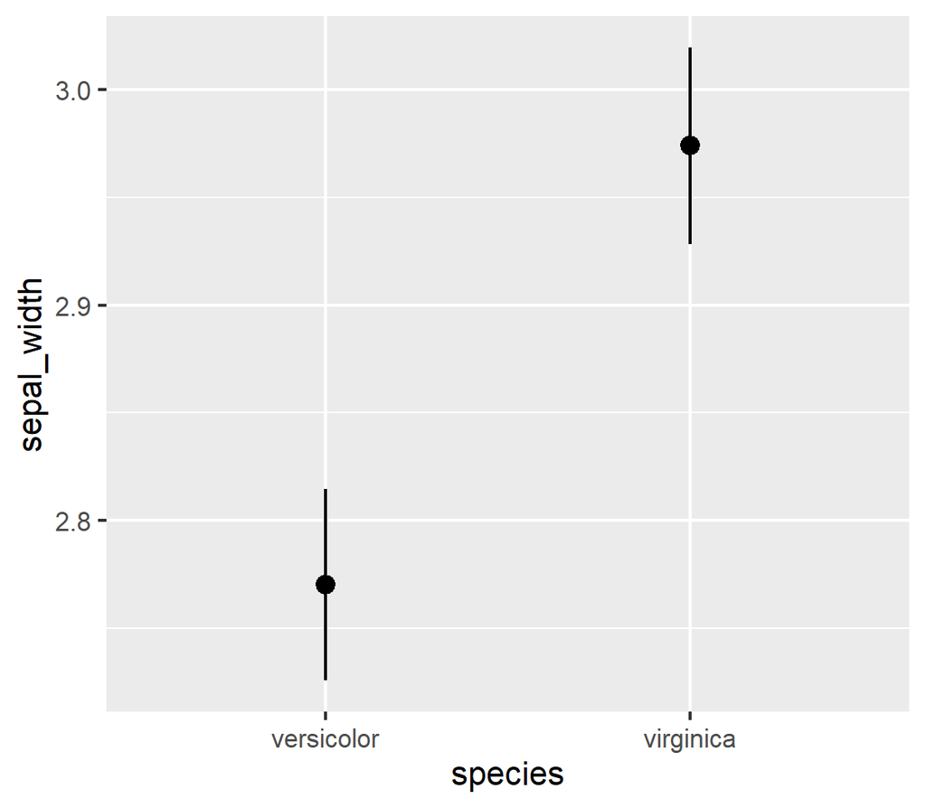

```r
ggplot(
  flowers,
  aes(x = species, y = sepal_width)
) +
  stat_summary()
```

- By default, `stat_summary()` shows the mean ± standard error (SE)

## Style means and error bars

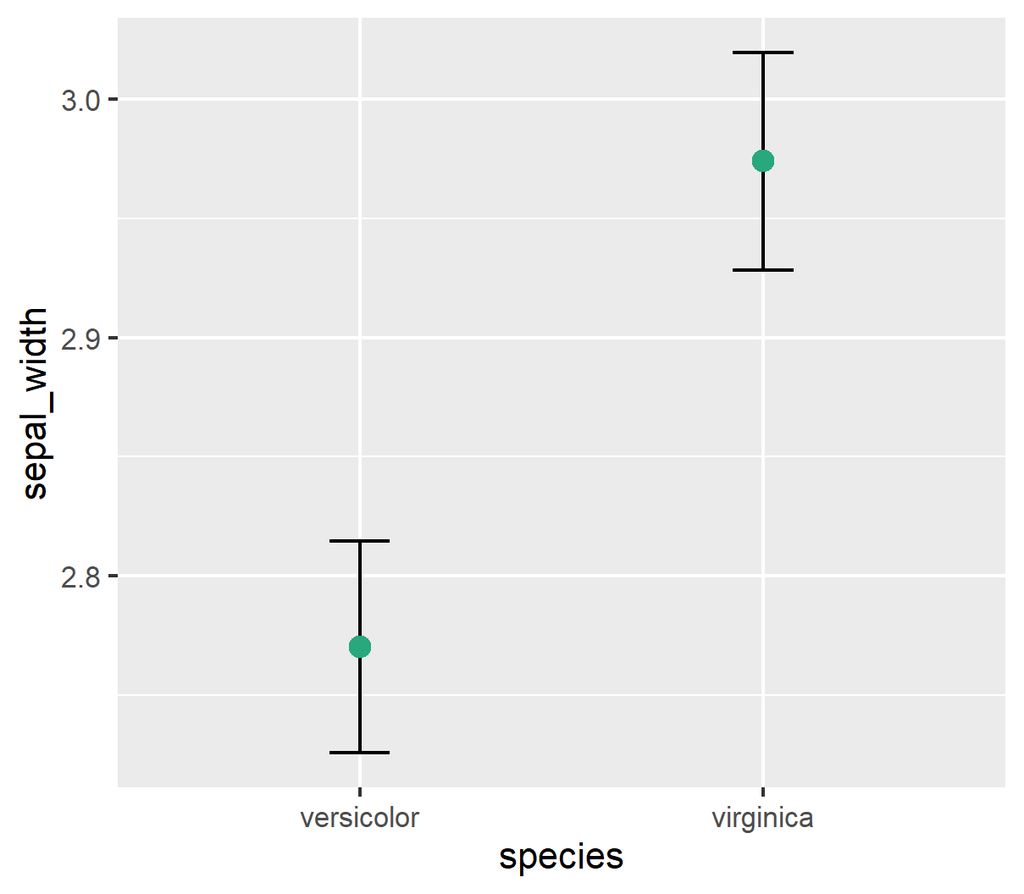

```r
ggplot(
  flowers,
  aes(x = species, y = sepal_width)
) +
  stat_summary(
    fun.data = mean_se,
    geom = "errorbar",
    width = 0.15
  ) +
  stat_summary(
    fun = mean,
    geom = "point",
    color = "#28a87d",
    size = 4
  )
```

- `fun.data` for error bars, `fun` for points

## Barplots with error bars

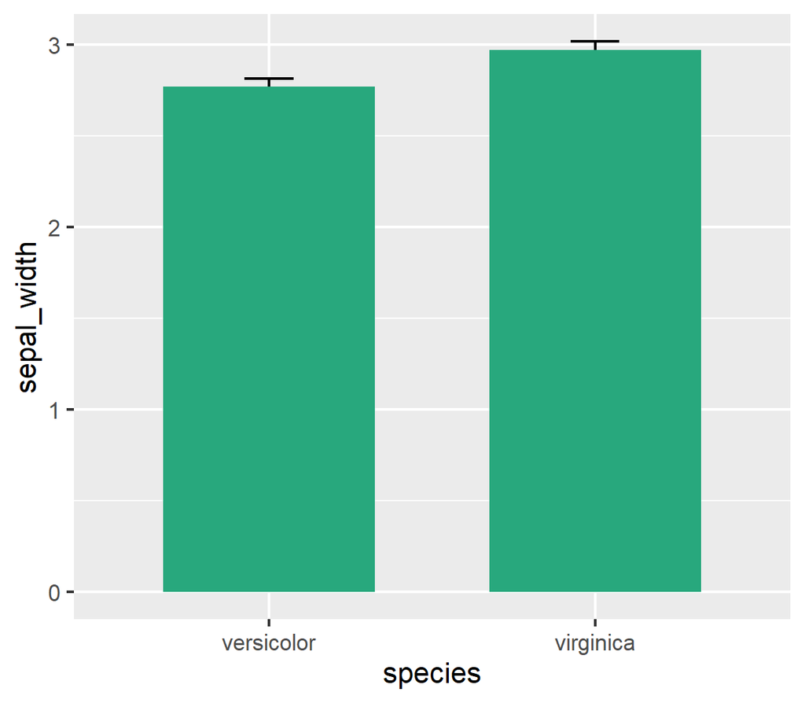

```r
ggplot(
  flowers,
  aes(x = species, y = sepal_width)
) +
  stat_summary(
    fun.data = mean_se,
    geom = "errorbar",
    width = 0.15
  ) +
  stat_summary(
    fun = mean,
    geom = "bar",
    fill = "#28a87d",
    width = 0.65
  )
```

## Add the test to the barplot

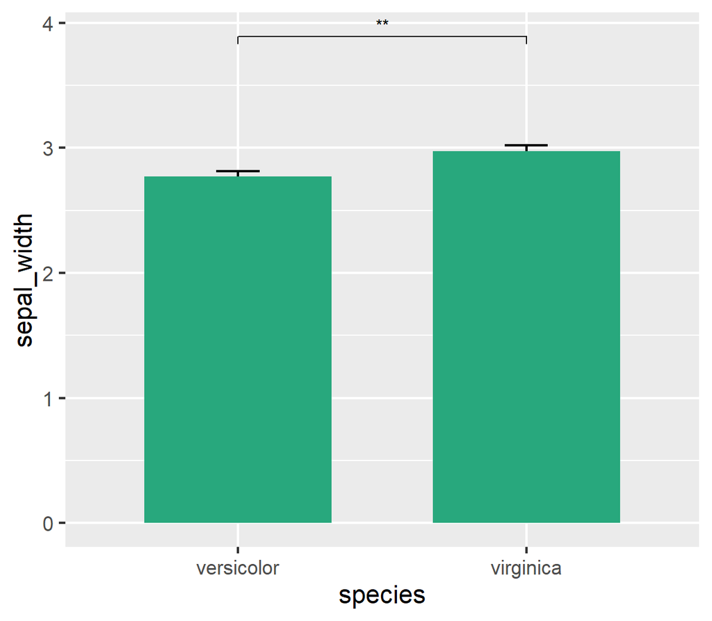

```r
ggplot(
  flowers,
  aes(x = species, y = sepal_width)
) +
  stat_summary(
    fun.data = mean_se,
    geom = "errorbar",
    width = 0.15
  ) +
  stat_summary(
    fun = mean,
    geom = "bar",
    fill = "#28a87d",
    width = 0.65
  ) +
  geom_signif(
    comparisons = list(
      c("versicolor", "virginica")
    ),
    test = "t.test",
    map_signif_level = TRUE
  )
```

# Comparing three groups

## Actually, there were three species

**Question:** Does the sepal width differ between the three iris species?

**Reproduce the data**

```r
flowers_all <- as_tibble(iris) |>
  select(sepal_width = Sepal.Width, species = Species)
```

```r
flowers_all |>
  summarize(
    n = n(),
    mean = mean(sepal_width),
    .by = species
  )
```

```
#> # A tibble: 3 × 3
#>   species        n  mean
#>   <fct>      <int> <dbl>
#> 1 setosa        50  3.43
#> 2 versicolor    50  2.77
#> 3 virginica     50  2.97
```

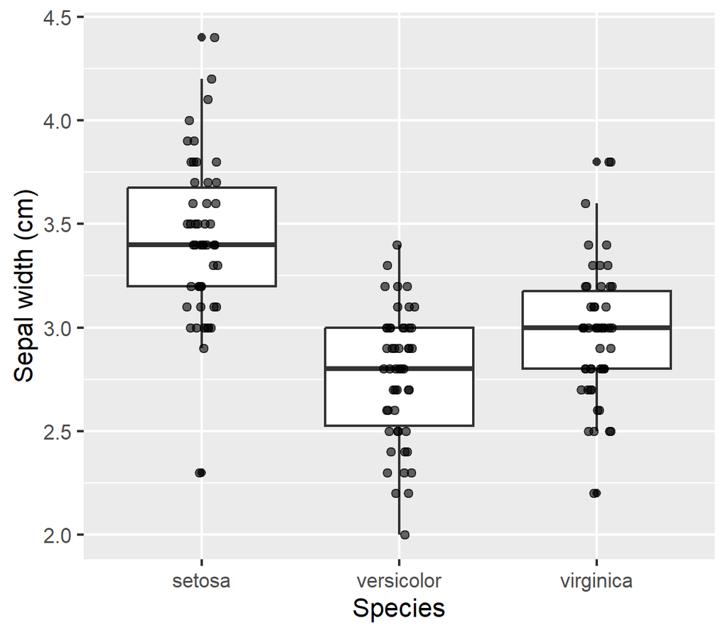

Could we just run 3 separate t-tests?

## Two kinds of errors

Every test decision can be wrong in two ways:

|  | $H_0$ is true (no difference) | $H_0$ is false (real difference) |
| --- | --- | --- |
| **Reject $H_0$** | **Type I error**: false positive (probability α) | Correct |
| **Do not reject $H_0$** | Correct | **Type II error**: false negative |

- With α = 0.05, we accept a 5% risk of a false positive
- Multiple testing increases the risk of a **type I error**

## Error-inflation with multiple testing

- For one test: Chance of false positive is 5% (at α = 0.05)
- This error potential increases with multiple tests:

$$P(\text{at least one false positive}) = 1 - (1 - \alpha)^k$$

with $k$ = number of tests

| Number of tests | Chance of at least one false positive |
| --- | --- |
| 1 | 5% |
| 3 | 14.3% |
| 10 | 40.1% |

Solution: p-value correction for multiple testing

## Pairwise comparisons in R

```r
pairwise.t.test(
  flowers_all$sepal_width,
  flowers_all$species,
  pool.sd = FALSE
)
```

```
#>
#>  Pairwise comparisons using t tests with non-pooled SD
#>
#> data:  flowers_all$sepal_width and flowers_all$species
#>
#>            setosa  versicolor
#> versicolor 7.5e-15 -
#> virginica  9.1e-09 0.0018
#>
#> P value adjustment method: holm
```

- `pool.sd = FALSE`: Welch’s t-test for each pair (the default uses one shared SD across all groups)
- The p-values are already adjusted (Holm method is the default)
- Rank-based alternative: `pairwise.wilcox.test()`

## Add the adjusted p-values to a plot

`geom_signif` can’t run pairwise tests, so we need to add p-values manually.

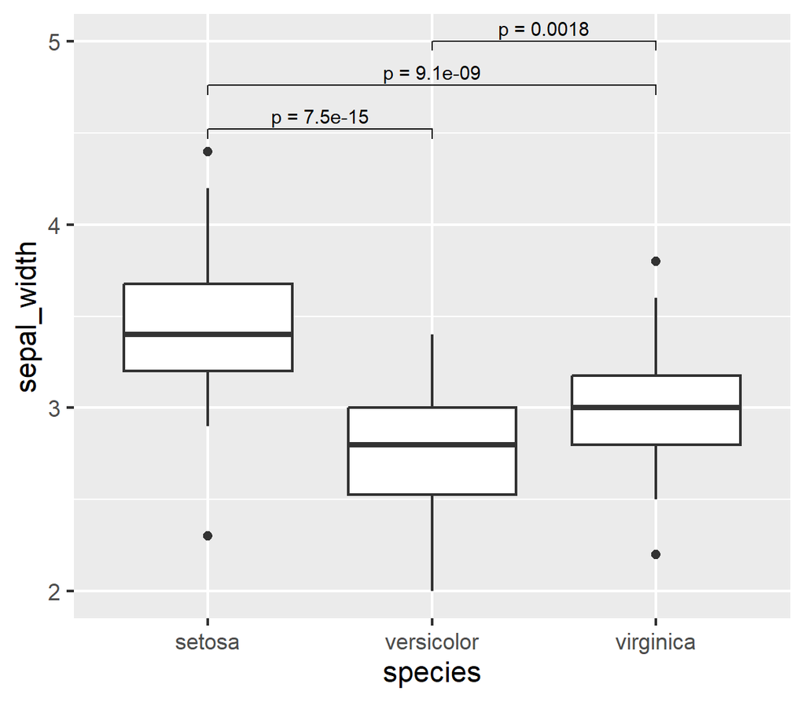

```r
ggplot(
  flowers_all,
  aes(x = species, y = sepal_width)
) +
  geom_boxplot() +
  geom_signif(
    comparisons = list(
      c("setosa", "versicolor"),
      c("setosa", "virginica"),
      c("versicolor", "virginica")
    ),
    annotations = c(
      "p = 7.5e-15",
      "p = 9.1e-09",
      "p = 0.0018"
    ),
    step_increase = 0.1,
    tip_length = 0.02
  )
```

- `annotations`: show our adjusted p-values (no new tests)
- `step_increase`: stack the brackets

## Extract the p-values automatically

Typing p-values by hand is error-prone. Extract them with `p["row", "column"]`:

```r
pairwise_results <- pairwise.t.test(
  flowers_all$sepal_width,
  flowers_all$species,
  pool.sd = FALSE
)
p <- pairwise_results$p.value

comparisons <- list(
  c("setosa", "versicolor"),
  c("setosa", "virginica"),
  c("versicolor", "virginica")
)
adjusted_p <- c(
  p["versicolor", "setosa"],
  p["virginica", "setosa"],
  p["virginica", "versicolor"]
)
p_labels <- paste(
  "p =",
  format.pval(adjusted_p, digits = 2)
)
```

```r
ggplot(
  flowers_all,
  aes(x = species, y = sepal_width)
) +
  geom_boxplot() +
  geom_signif(
    comparisons = comparisons,
    annotations = p_labels,
    step_increase = 0.1,
    tip_length = 0.02
  )
```

## Add the test results to the barplot

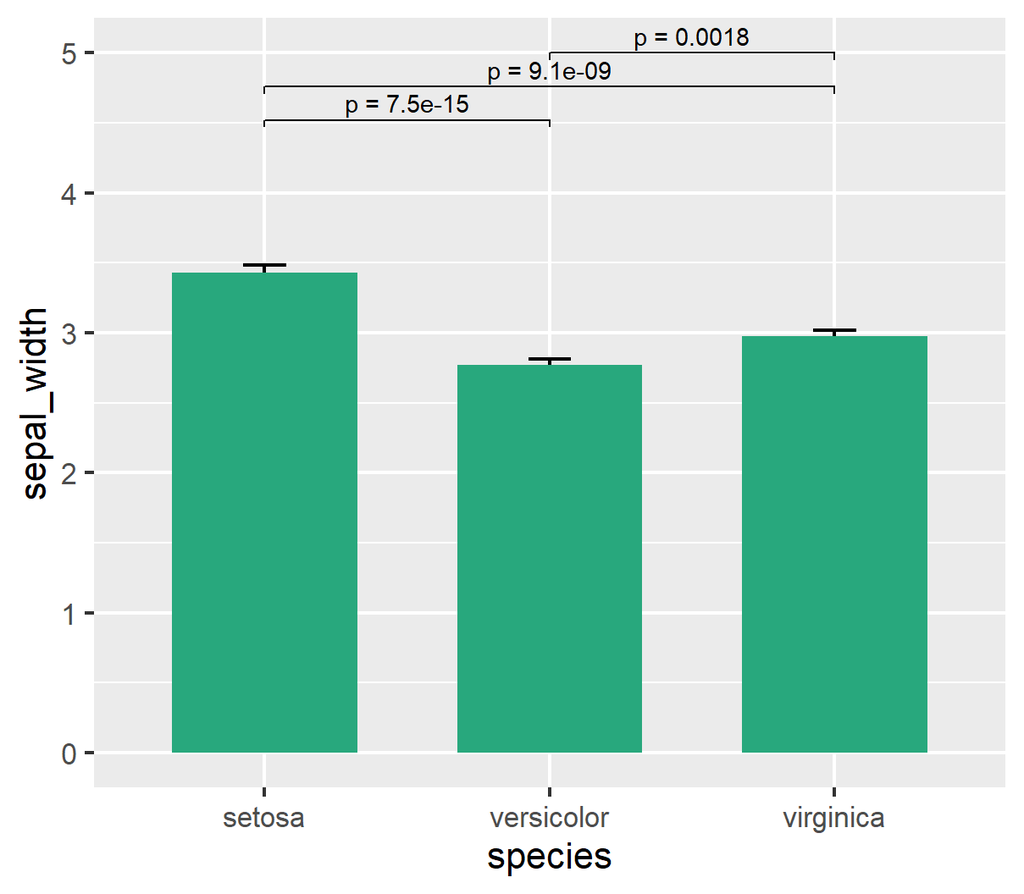

```r
ggplot(
  flowers_all,
  aes(x = species, y = sepal_width)
) +
  stat_summary(
    fun.data = mean_se,
    geom = "errorbar",
    width = 0.15
  ) +
  stat_summary(
    fun = mean,
    geom = "bar",
    fill = "#28a87d",
    width = 0.65
  ) +
  geom_signif(
    comparisons = comparisons,
    annotations = p_labels,
    step_increase = 0.1,
    tip_length = 0.02
  )
```

# Now you

Task (45 min)

Statistical tests with penguins

**Find the task description [here](https://selinazitrone.github.io/intro-r-data-analysis/sessions/tasks/tests-task.html)**